# Model Building: Predictors of Eviction in Brooklyn, 2010-2016

### Count-based outcome (Poisson)

Since our outcome, eviction rate, is calculated using a **count** variable (number of evictions) repeated over time within areas, we’ll model it using GEE with a Poisson link function.

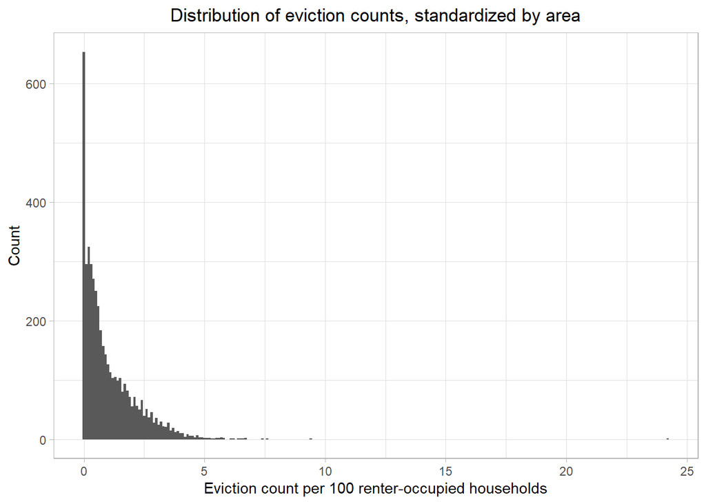

**Model:**

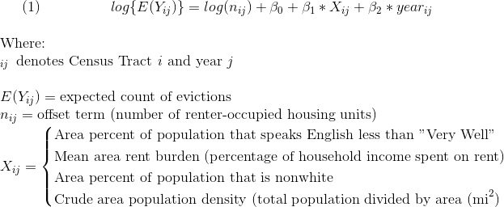

#### Univariable Poisson GEE models

```r
## trying glm with Poisson
univariate_poi = function(x){

  gee_poi = geeglm(evictions ~
                   #(eviction_filings - evictions) ~ ## testing discrepancy in rate as outcome - subtracted counts, kept offset
                   offset(log(renter_occupied_households)) + x + years_since_2010, ## here i removed the int term
                   data = joined_data_bklyn_nomissing,
                   id = geoid,
                   family = poisson,
                   corstr = "ar1") %>% ## ar(1) corstr due to autocorrelation in data across time
  broom::tidy(conf.int = FALSE,
              conf.level = 0.95,
              exponentiate = FALSE,
              quick = FALSE)
  tibble(
    b0_est = gee_poi[[1,2]],
    b0_p = gee_poi[[1,5]],
    b1_est = gee_poi[[2,2]],
    RR = exp(gee_poi[[2,2]]),
    RR_10 = exp(gee_poi[[2,2]]*10),
    b1_p = gee_poi[[2,5]],
    year_b2_est = gee_poi[[3,2]],
    year_RR = exp(gee_poi[[3,2]]),
    year_p = gee_poi[[3,5]],
    # interaction_est = gee_poi[[4,2]], ## removed the int term
    # interaction_p = gee_poi[[4,5]]
  )

}

pred_poi_list = list("pct_eng" = pull(joined_data_bklyn_nomissing, pct_eng),
                     "rent_burden" = pull(joined_data_bklyn_nomissing, rent_burden),
                     "pct_nonwhite" = pull(joined_data_bklyn_nomissing, pct_nonwhite_racedata),
                     "pop_density" = pull(joined_data_bklyn_nomissing, total_pop_densitydata)
                     )

gee_poi_output = map(pred_poi_list, univariate_poi) %>%
  do.call(rbind, .) %>%
  knitr::kable(digits = 2,
               caption = "Univarable GEE parameter estimates: predicted change in rate of evictions (standardized by area-specific number of renter-occupied households)")

gee_poi_output
```

Univarable GEE parameter estimates: predicted change in rate of evictions (standardized by area-specific number of renter-occupied households)

|  | b0_est | b0_p | b1_est | RR | RR_10 | b1_p | year_b2_est | year_RR | year_p |
| --- | --- | --- | --- | --- | --- | --- | --- | --- | --- |
| pct_eng | -3.91 | 0 | -0.02 | 0.98 | 0.82 | 0.00 | -0.05 | 0.95 | 0 |
| rent_burden | -4.65 | 0 | 0.01 | 1.01 | 1.11 | 0.03 | -0.05 | 0.95 | 0 |
| pct_nonwhite | -6.04 | 0 | 0.02 | 1.02 | 1.23 | 0.00 | 0.03 | 1.03 | 0 |
| pop_density | -4.34 | 0 | 0.00 | 1.00 | 1.00 | 0.66 | -0.05 | 0.95 | 0 |

However, we see that when controlling for percent African Americans comprising a community, the association between `pct_eng` and `evictions` flips. Above, we see that as `pct_eng` - the percentage of individuals who speak English less than ‘Very Well’- goes up, eviction rates decrease, on average.

African Americans are a predominantly English-speaking community in the US but are nonetheless more vulnerable to evictions than White individuals. In this way, the relationship between `pct_eng` and `evictions` was actually being confounded by the percentage of African Americans in a community: a group with high rates of English fluency, and a predominant population in many areas of Brooklyn, was still experiencing higher rates of eviction.

Thus, after controlling for `pct_af_am`, we see the following estimates for `pct_eng` predicting `evictions`:

| b0_est | b0_p | b1_est | RR | RR_10 | b1_p | year_b2_est | year_RR | year_p |
| --- | --- | --- | --- | --- | --- | --- | --- | --- |
| -5.7 | 0 | 0.01 | 1.01 | 1.09 | 0 | 0.02 | 1.02 | 0 |

As we can see, the association has been flipped, and the relationship between English non-fluency and eviction is positive, controlling for percentage of African Americans.

#### Multivariable Poisson GEE model

Since the effect of population density on eviction count wasn’t statistically significant, controlling for year, we won’t include it in our multivariable model. Thus, our multivariable model will take the form:

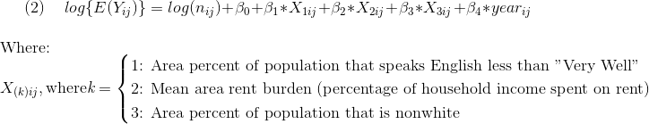

**Next Steps**

- Correlation analysis of predictors (prevent multicollinearity)
- Raw plots of predictor vs. outcome? Log outcome? How to visualize?
- Model building process ideas:
  - Fit vs. Residual plots, with investigation of outliers
  - Compare models to saturated models (i.e. all main effects and interaction terms)
  - Cross-validation of models
- Shiny app that builds model based on any variable we have (output = # evictions per 100 renter households per year)

## Correlation Plot

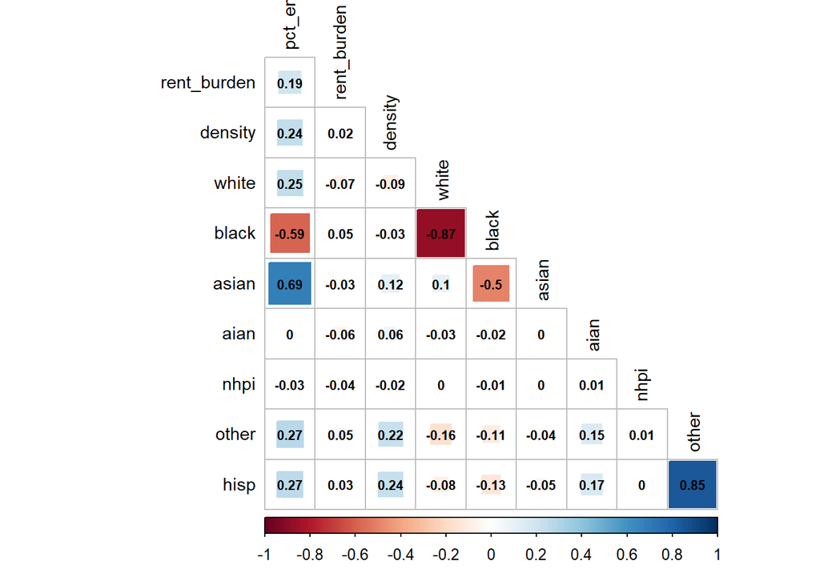

```r
joined_data_bklyn_nomissing %>%
  #select(-pct_nonwhite_racedata, -pct_af_am, am_ind_ak_native = aian) %>%
  select(pct_eng, rent_burden, density,
           white, black, asian, aian, nhpi, other, hisp) %>%
  select_if(is.numeric) %>%
  cor() %>%
  corrplot::corrplot(type = "lower",
                     method = "square",
                     addCoef.col = "black",
                     diag = FALSE,
                     number.cex = .7,
                     tl.col = "black",
                     tl.cex = .9)
```

```r
## NOTES
  ## include hisp instead of other, since highly correlated
  ## include black not white, since highly correlated
  ## fit two models:
      ## one to look at pct_eng, controlling for race (pct_eng + all races except white, other + other predictors)
      ## one to just look at race (all races except white, other + other predictors)
```

## Hypothesized Model

```r
hyp_model =
  geeglm(evictions ~
           offset(log(renter_occupied_households)) +
           years_since_2010 +
           pct_eng + rent_burden + density +
           white + black + asian + aian + nhpi + other + hisp,
         data = joined_data_bklyn_nomissing,
         id = geoid,
         family = poisson,
         corstr = "ar1")

hyp_model %>%
  broom::tidy() %>%
  knitr::kable()
```

| term | estimate | std.error | statistic | p.value |
| --- | --- | --- | --- | --- |
| (Intercept) | -5.3389318 | 0.7675154 | 48.387653 | 0.0000000 |
| years_since_2010 | 0.0573695 | 0.0051551 | 123.846652 | 0.0000000 |
| pct_eng | 0.0049948 | 0.0016666 | 8.981867 | 0.0027267 |
| rent_burden | 0.0157129 | 0.0023663 | 44.094017 | 0.0000000 |
| density | -0.0000037 | 0.0000007 | 26.212219 | 0.0000003 |
| white | -0.0104127 | 0.0073552 | 2.004176 | 0.1568665 |
| black | 0.0097395 | 0.0074365 | 1.715283 | 0.1903014 |
| asian | -0.0087806 | 0.0074362 | 1.394277 | 0.2376842 |
| aian | -0.0209891 | 0.0143568 | 2.137347 | 0.1437503 |
| nhpi | 0.0357599 | 0.0325690 | 1.205545 | 0.2722163 |
| other | -0.0112590 | 0.0073931 | 2.319254 | 0.1277813 |
| hisp | 0.0109199 | 0.0014112 | 59.880696 | 0.0000000 |

```r
## need to include `black` since confounds pct_eng -> evictions relationship
  ## but `black` also collinear with `pct_nonwhite`, which we want as a predictor
  ## solution: include all races EXCEPT WHITE AND OTHER in one analysis (interpret races)
  ## then include races (minus white and hispanic) + pct_eng (ESL controlling for races)
```

## Model Fitting using `gee_stepper`

```r
## use full dataset
full_fit =
  geeglm(evictions ~
           offset(log(renter_occupied_households)) + years_since_2010 +
           pct_eng + rent_burden + pct_nonwhite_racedata + density + ## hypothesized
           black + aian + asian + nhpi + other + hisp + ## race
           poverty_rate + pct_renter_occupied + median_gross_rent + median_household_income + median_property_value,
         data = joined_data_bklyn_nomissing,
         id = geoid,
         family = poisson,
         corstr = "ar1")

# gee_stepper_o(full_fit, formula(full_fit)) ## customized function to automatically include offset and time covariate
```

Final formula:

```r
step_model =
  geeglm(formula = evictions ~ offset(log(renter_occupied_households)) +
           years_since_2010 +
           black + hisp + aian + asian + nhpi +
           rent_burden + median_gross_rent + density + pct_eng + poverty_rate + median_household_income,
         family = poisson,
         data = joined_data_bklyn_nomissing,
         id = geoid,
         corstr = "ar1")
```

# Outline

## Outcome

### Distribution

## Relevant predictors

## Hypothesis

### Raw plots of hypothesized predictors

### Discussion of confounding of `black` on `pct_eng` -> `evictions`

## Correlation matrix

## Model building

### Hypothesized models

- With `pct_eng`
- Without `pct_eng`

### Stepwise model

## Residual vs. fit of each

## Cross-validation of each

## Conclusions